# TP Final - Calidad de datos en las elecciones 2023

### Integrantes:

- Curti, Tomás
- D'Aloisio, Camilo
- de Otazua, Agustin

### Librerías

```python
import pandas as pd
import seaborn as sns
from matplotlib import pyplot as plt
```

### Datos

Cargamos los datos de la Elección General 2023 para las provincias de Chaco, Formosa y Santiago del Estero.

```python
datos_generales_g10 = pd.read_csv("ResultadoElectorales_2023_Generales_G10.csv", index_col=0)
```

```python
datos_generales_g10.head()
```

|  | año | eleccion_tipo | eleccion_id | recuento_tipo | recuento_id | padron_tipo | distrito_id | distrito_nombre | seccionprovincial_id | seccionprovincial_nombre | ... | mesa_tipo | mesa_electores | cargo_id | cargo_nombre | agrupacion_id | agrupacion_nombre | lista_numero | lista_nombre | votos_tipo | votos_cantidad |
| --- | --- | --- | --- | --- | --- | --- | --- | --- | --- | --- | --- | --- | --- | --- | --- | --- | --- | --- | --- | --- | --- |
| 583150 | 2023 | GENERAL | 2 | PROVISORIO | 1 | NORMAL | 6 | Chaco | NaN | NaN | ... | NATIVOS | 343 | 1 | PRESIDENTE Y VICE | 132 | JUNTOS POR EL CAMBIO | NaN | NaN | POSITIVO | 121 |
| 583151 | 2023 | GENERAL | 2 | PROVISORIO | 1 | NORMAL | 6 | Chaco | NaN | NaN | ... | NATIVOS | 343 | 1 | PRESIDENTE Y VICE | 135 | LA LIBERTAD AVANZA | NaN | NaN | POSITIVO | 85 |
| 583152 | 2023 | GENERAL | 2 | PROVISORIO | 1 | NORMAL | 6 | Chaco | NaN | NaN | ... | NATIVOS | 343 | 1 | PRESIDENTE Y VICE | 134 | UNION POR LA PATRIA | NaN | NaN | POSITIVO | 43 |
| 583153 | 2023 | GENERAL | 2 | PROVISORIO | 1 | NORMAL | 6 | Chaco | NaN | NaN | ... | NATIVOS | 343 | 1 | PRESIDENTE Y VICE | 133 | HACEMOS POR NUESTRO PAIS | NaN | NaN | POSITIVO | 11 |
| 583154 | 2023 | GENERAL | 2 | PROVISORIO | 1 | NORMAL | 6 | Chaco | NaN | NaN | ... | NATIVOS | 343 | 1 | PRESIDENTE Y VICE | 136 | FRENTE DE IZQUIERDA Y DE TRABAJADORES - UNIDAD | NaN | NaN | POSITIVO | 0 |

5 rows × 25 columns

### Análisis descriptivo de los datos

Tiene 25 columnas:

```python
print(datos_generales_g10.columns)
```

```
Index(['año', 'eleccion_tipo', 'eleccion_id', 'recuento_tipo', 'recuento_id',
       'padron_tipo', 'distrito_id', 'distrito_nombre', 'seccionprovincial_id',
       'seccionprovincial_nombre', 'seccion_id', 'seccion_nombre',
       'circuito_id', 'circuito_nombre', 'mesa_id', 'mesa_tipo',
       'mesa_electores', 'cargo_id', 'cargo_nombre', 'agrupacion_id',
       'agrupacion_nombre', 'lista_numero', 'lista_nombre', 'votos_tipo',
       'votos_cantidad'],
      dtype='object')
```

- **año**: año de la elección
- **eleccion_tipo**: PASO, Generales o Balotaje.
- **eleccion_id**: id del tipo de elección (2: Generales).
- **recuento_tipo**: PROVISORIO
- **recuento_id**: 1
- **padron_tipo**: NORMAL
- **distrito_id**: Id que se le da a cada provincia
- **distrito_nombre**: Nombre de la provincia
- **seccionprovincial_id**: Esta todo vacio
- **seccionprovincial_nombre**:Esta todo vacio
- **seccion_id** : id de la localidad en la provincia
- **seccion_nombre**: nombre de la locaclidad en la provincia
- **circuito_id**: id del circuito
- **circuito_nombre**: nombre del circuito que es lo mismo que el id
- **mesa_id**: Id de mesa
- **mesa_tipo**: NATIVOS
- **mesa_electores**: Numero de la mesa
- **cargo_id**: Numero de id para el cargo al cual se esta votando
- **cargo_nombre**: Para que cargo se esta votando
- **agrupacion_id**: Numero del partido
- **agrupacion_nombre**: Nombre del partido
- **lista_numero**: Esta vacia, esta columna solo tiene relevancia en las paso cuando un partido puede tener mas de un candidato
- **lista_nombre**: Esta vacia, esta columna solo tiene relevancia en las paso cuando un partido puede tener mas de un candidato
- **votos_tipo**: Tipo de voto, si fue positivo, se anulo, se impugno, etc
- **votos_cantidad**: Cantidad de votos que saco el agrupado de todas las condiciones anteriores

Analizamos cuántos registros hay de cada provincia.

```python
datos_generales_g10["distrito_nombre"].value_counts()
```

```
Chaco                  106092
Santiago del Estero     88704
Formosa                 65296
Name: distrito_nombre, dtype: int64
```

Vemos la cantidad de valores faltantes que hay por columna:

- Observamos que las columnas 'seccionprovincial_id', 'seccionprovincial_nombre', 'lista_numero' y 'lista_nombre' están completamente vacías.
- Por otro lado, un 55,9% de los registros en la columna 'agrupacion_nombre' están vacíos. Esto se debe a que cuando un voto no es válido (distinto a "POSITIVO" en la columna "votos_tipo") no se llena el campo de 'agrupacion_nombre', aunque si se llena el de 'agrupacion_id' con un 0.
- El resto de los columnas no poseen datos faltantes.

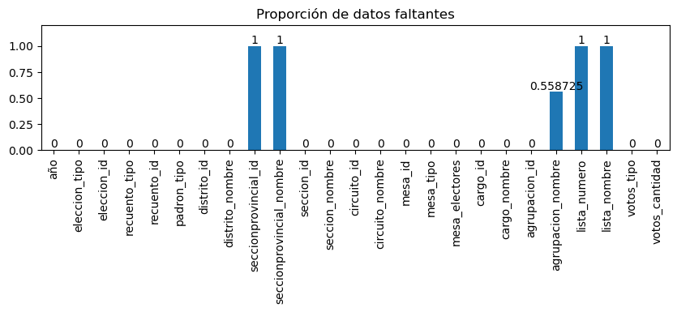

```python
datos_faltantes = datos_generales_g10.isna().sum(axis=0) / len(datos_generales_g10)
ax = datos_faltantes.plot.bar(figsize = (10, 2), title = "Proporción de datos faltantes")
ax.bar_label(ax.containers[0])
ax.set_ylim((0, 1.2))
plt.show()
```

```python
datos_generales_g10[datos_generales_g10["votos_tipo"] != "POSITIVO"]["agrupacion_nombre"].value_counts()
```

```
Series([], Name: agrupacion_nombre, dtype: int64)
```

```python
datos_generales_g10[datos_generales_g10["votos_tipo"] != "POSITIVO"]["agrupacion_id"].value_counts()
```

```
0    145320
Name: agrupacion_id, dtype: int64
```

Casi todas las mesas tienen capacidad máxima de votantes de entre 300 y 350 personas.

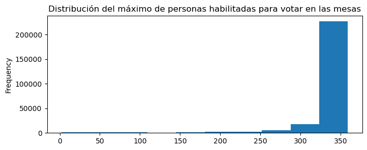

```python
datos_generales_g10["mesa_electores"].plot.hist(figsize = (8, 3), title="Distribución del máximo de personas habilitadas para votar en las mesas")
```

Analizamos si hay valores repetidos en las columnas

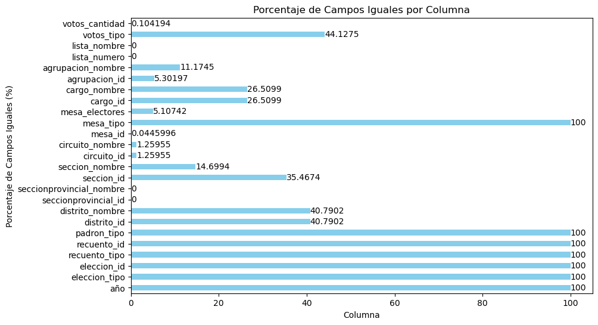

```python
porcentaje_iguales = (datos_generales_g10.apply(lambda col: col == col.iloc[0]).sum() / len(datos_generales_g10)) * 100

plt.figure(figsize=(10, 6))
ax = porcentaje_iguales.plot(kind='barh', color='skyblue')
ax.bar_label(ax.containers[0])
plt.title('Porcentaje de Campos Iguales por Columna')
plt.xlabel('Columna')
plt.ylabel('Porcentaje de Campos Iguales (%)')
plt.show()
```

Como podemos ver, las columnas de año, **eleccion_tipo**, **eleccion_id**, **recuento_tipo**, **padron_tipo** y **mesa_tipo** solo tienen una respuesta.

Esto se debe a que son valores "obvios" dentro del contexto en el cual estamos analizando, como lo puede ser el año (2023) o tipo de eleccion (Generales).

### Análisis de proporción de votos por partido y cargo

Queremos analizar las distribuciones, visualizadas mediante boxplots, de la proporción de votos que sacó cada partido en cada cargo y provincia.

Para cada provincia, mostraremos primero los resultados de las agregaciones a lo largo de la secciones de dicha provincia y luego a lo largo de todas las mesas.

#### Formosa

- **Por sección**

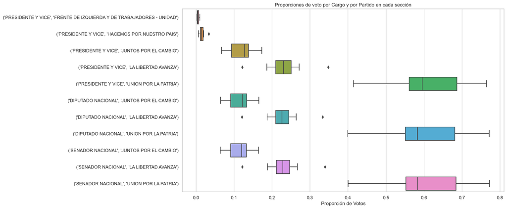

```python
cargos = ['PRESIDENTE Y VICE', 'DIPUTADO NACIONAL', 'SENADOR NACIONAL']

formosa_df = datos_generales_g10[datos_generales_g10['distrito_nombre'] == 'Formosa']
total_por_mesa_por_partido = formosa_df.pivot_table(values='votos_cantidad',
                                          index=['seccion_id'],
                                          columns=['cargo_nombre', 'agrupacion_nombre'],
                                          aggfunc='sum',
                                          fill_value=0).reset_index()[cargos]

total_por_mesa = formosa_df.pivot_table(values='votos_cantidad',
                                          index=['seccion_id'],
                                          columns=['cargo_nombre'],
                                          aggfunc='sum',
                                          fill_value=0).reset_index()[cargos]

proporcion_por_mesa_por_partido = total_por_mesa_por_partido / total_por_mesa


sns.set(style="whitegrid")
plt.figure(figsize=(14, 8))
sns.boxplot(data=proporcion_por_mesa_por_partido, orient='h')
plt.title('Proporciones de voto por Cargo y por Partido en cada sección')
plt.xlabel('Proporción de Votos')
plt.show()
```

- **Por mesa**

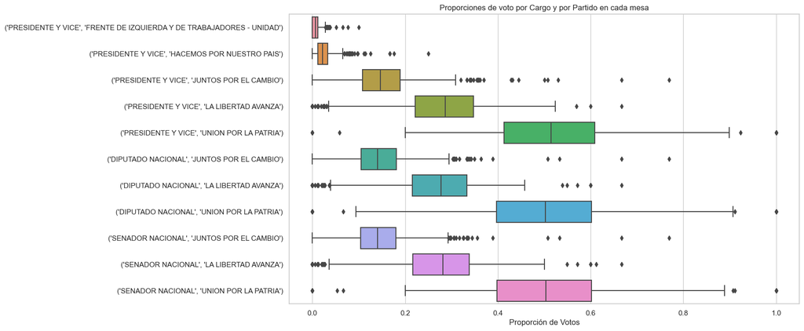

```python
cargos = ['PRESIDENTE Y VICE', 'DIPUTADO NACIONAL', 'SENADOR NACIONAL']

formosa_df = datos_generales_g10[datos_generales_g10['distrito_nombre'] == 'Formosa']
total_por_mesa_por_partido = formosa_df.pivot_table(values='votos_cantidad',
                                          index=['mesa_id', 'circuito_id'],
                                          columns=['cargo_nombre', 'agrupacion_nombre'],
                                          aggfunc='sum',
                                          fill_value=0).reset_index()[cargos]

total_por_mesa = formosa_df.pivot_table(values='votos_cantidad',
                                          index=['mesa_id', 'circuito_id'],
                                          columns=['cargo_nombre'],
                                          aggfunc='sum',
                                          fill_value=0).reset_index()[cargos]

proporcion_por_mesa_por_partido = total_por_mesa_por_partido / total_por_mesa


sns.set(style="whitegrid")
plt.figure(figsize=(14, 8))
sns.boxplot(data=proporcion_por_mesa_por_partido, orient='h')
plt.title('Proporciones de voto por Cargo y por Partido en cada mesa')
plt.xlabel('Proporción de Votos')
plt.show()
```

Como puede verse, la distribuciones por sección están mucho más alejadas entre sí que en el caso del análisis por mesa. Esto se debe a que la variabilidad por mesa es mucho más alta, ya que pueden haber secciones con muchos votantes (una capital por ejemplo) que elijan mayoritariamente un partido, tirando los estadísticos para su dirección. En cambio, en el caso de analizar por sección se normarliza según el número de mesas en la misma, brindando igual representatividad entre territorios.

Por ejemplo, viendo el análisis por sección se podría concluir que Unión por la Patria superó en gran medida (casi un 40%) a los otros partidos en cuanto a distribución territorial, pero si analizamos por mesa vemos que la diferencia es menor (20-30%).

Otra diferencia que se observa es que casi no hay outliers en el caso del análisis por sección, dando a entender que no hay secciones que se comporten drásticamente distintas al resto.

#### Chaco

En Chaco no se eligió para Senadores en las elecciones Generales de octubre.

- **Por sección**

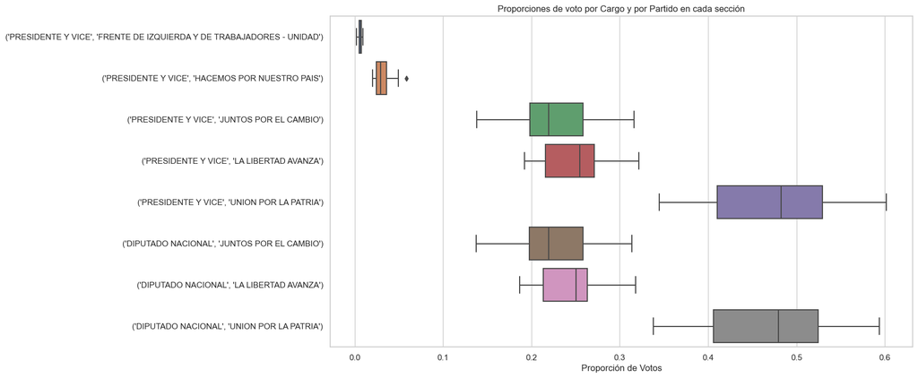

```python
cargos = ['PRESIDENTE Y VICE', 'DIPUTADO NACIONAL']

chaco_df = datos_generales_g10[datos_generales_g10['distrito_nombre'] == 'Chaco']
total_por_mesa_por_partido = chaco_df.pivot_table(values='votos_cantidad',
                                          index=['seccion_id'],
                                          columns=['cargo_nombre', 'agrupacion_nombre'],
                                          aggfunc='sum',
                                          fill_value=0).reset_index()[cargos]

total_por_mesa = chaco_df.pivot_table(values='votos_cantidad',
                                          index=['seccion_id'],
                                          columns=['cargo_nombre'],
                                          aggfunc='sum',
                                          fill_value=0).reset_index()[cargos]

proporcion_por_mesa_por_partido = total_por_mesa_por_partido / total_por_mesa


sns.set(style="whitegrid")
plt.figure(figsize=(14, 8))
sns.boxplot(data=proporcion_por_mesa_por_partido, orient='h')
plt.title('Proporciones de voto por Cargo y por Partido en cada sección')
plt.xlabel('Proporción de Votos')
plt.show()
```

- **Por mesa**

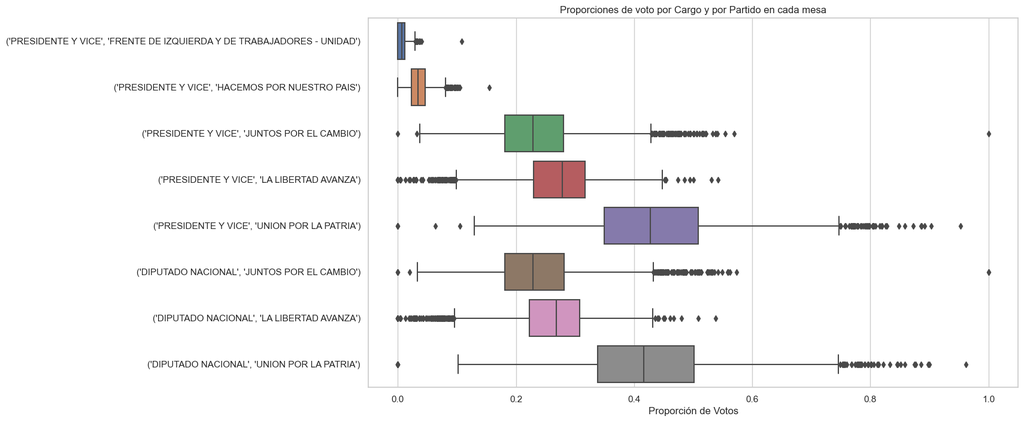

```python
cargos = ['PRESIDENTE Y VICE', 'DIPUTADO NACIONAL']

chaco_df = datos_generales_g10[datos_generales_g10['distrito_nombre'] == 'Chaco']
total_por_mesa_por_partido = chaco_df.pivot_table(values='votos_cantidad',
                                          index=['mesa_id', 'circuito_id'],
                                          columns=['cargo_nombre', 'agrupacion_nombre'],
                                          aggfunc='sum',
                                          fill_value=0).reset_index()[cargos]

total_por_mesa = chaco_df.pivot_table(values='votos_cantidad',
                                          index=['mesa_id', 'circuito_id'],
                                          columns=['cargo_nombre'],
                                          aggfunc='sum',
                                          fill_value=0).reset_index()[cargos]

proporcion_por_mesa_por_partido = total_por_mesa_por_partido / total_por_mesa


sns.set(style="whitegrid")
plt.figure(figsize=(14, 8))
sns.boxplot(data=proporcion_por_mesa_por_partido, orient='h')
plt.title('Proporciones de voto por Cargo y por Partido en cada mesa')
plt.xlabel('Proporción de Votos')
plt.show()
```

Se observa el mismo fenómeno que en Formosa, mostrando una clara ventaja territorial de Unión por la Patria pero con una brecha menor en votos totales.

#### Santiago del Estero

Tampoco hay datos de Senadores.

- **Por sección**

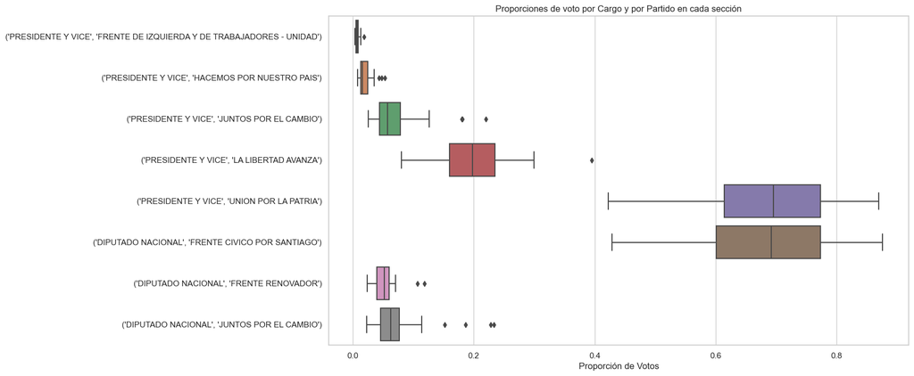

```python
cargos = ['PRESIDENTE Y VICE', 'DIPUTADO NACIONAL']

santiago_df = datos_generales_g10[datos_generales_g10['distrito_nombre'] == 'Santiago del Estero']
total_por_mesa_por_partido = santiago_df.pivot_table(values='votos_cantidad',
                                          index=['seccion_id'],
                                          columns=['cargo_nombre', 'agrupacion_nombre'],
                                          aggfunc='sum',
                                          fill_value=0).reset_index()[cargos]

total_por_mesa = santiago_df.pivot_table(values='votos_cantidad',
                                          index=['seccion_id'],
                                          columns=['cargo_nombre'],
                                          aggfunc='sum',
                                          fill_value=0).reset_index()[cargos]

proporcion_por_mesa_por_partido = total_por_mesa_por_partido / total_por_mesa


sns.set(style="whitegrid")
plt.figure(figsize=(14, 8))
sns.boxplot(data=proporcion_por_mesa_por_partido, orient='h')
plt.title('Proporciones de voto por Cargo y por Partido en cada sección')
plt.xlabel('Proporción de Votos')
plt.show()
```

- **Por mesa**

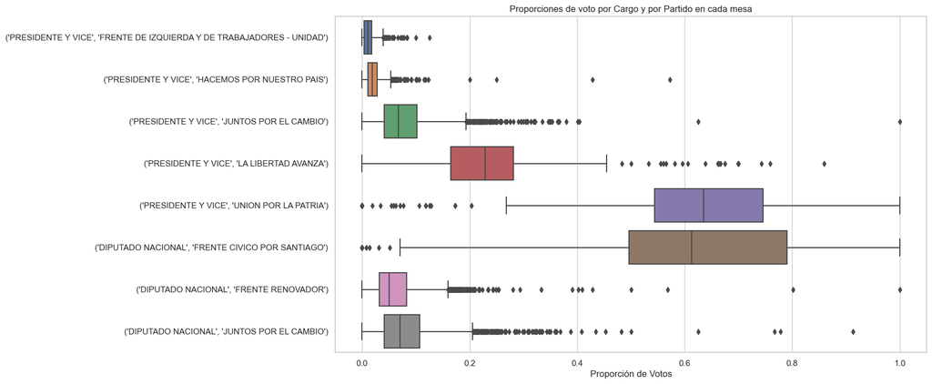

```python
cargos = ['PRESIDENTE Y VICE', 'DIPUTADO NACIONAL']

santiago_df = datos_generales_g10[datos_generales_g10['distrito_nombre'] == 'Santiago del Estero']
total_por_mesa_por_partido = santiago_df.pivot_table(values='votos_cantidad',
                                          index=['mesa_id', 'circuito_id'],
                                          columns=['cargo_nombre', 'agrupacion_nombre'],
                                          aggfunc='sum',
                                          fill_value=0).reset_index()[cargos]

total_por_mesa = santiago_df.pivot_table(values='votos_cantidad',
                                          index=['mesa_id', 'circuito_id'],
                                          columns=['cargo_nombre'],
                                          aggfunc='sum',
                                          fill_value=0).reset_index()[cargos]

proporcion_por_mesa_por_partido = total_por_mesa_por_partido / total_por_mesa


sns.set(style="whitegrid")
plt.figure(figsize=(14, 8))
sns.boxplot(data=proporcion_por_mesa_por_partido, orient='h')
plt.title('Proporciones de voto por Cargo y por Partido en cada mesa')
plt.xlabel('Proporción de Votos')
plt.show()
```

En este caso, si bien se achica la brecha entre votos territoriales y totales, el cambio es menor con respecto a Formosa y Chaco.

### Análisis de correlación de votos entre cargos

Queremos analizar en cada provincia y partido si hay una correlación entre los votos totales, de cada mesa, para Presidente-Vice y Diputados.

Para ello, graficamos un diagrama de dispersión de dichos cargos, diferenciando por provincia y partido.

```python
colores_3_partidos = {'JUNTOS POR EL CAMBIO':"#FEDD00", 'LA LIBERTAD AVANZA' : "#753BBD", 'UNION POR LA PATRIA' : "#009CDE"}
```

#### Formosa

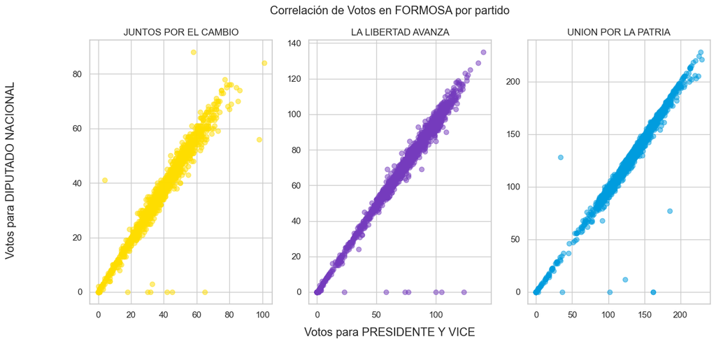

```python
formosa_df = datos_generales_g10[datos_generales_g10['distrito_nombre'] == 'Formosa']
presidenciales_formosa_df = formosa_df[formosa_df['cargo_nombre'] == 'PRESIDENTE Y VICE']
diputados_formosa_df = formosa_df[formosa_df['cargo_nombre'] == 'DIPUTADO NACIONAL']

presidenciales_pivot_formosa = presidenciales_formosa_df.pivot_table(values='votos_cantidad',
                                                                     index=['mesa_id', 'circuito_id'],
                                                                     columns='agrupacion_nombre',
                                                                     aggfunc='sum',
                                                                     fill_value=0).reset_index()

diputados_pivot_formosa = diputados_formosa_df.pivot_table(values='votos_cantidad',
                                                           index=['mesa_id', 'circuito_id'],
                                                           columns='agrupacion_nombre',
                                                           aggfunc='sum',
                                                           fill_value=0).reset_index()

merged_formosa_df = pd.merge(presidenciales_pivot_formosa, diputados_pivot_formosa, on=['mesa_id', 'circuito_id'])

partidos = ['JUNTOS POR EL CAMBIO', 'LA LIBERTAD AVANZA', 'UNION POR LA PATRIA']
fig, axs = plt.subplots(1, 3, figsize = (14, 6))
for i, partido in enumerate(partidos):
    axs[i].scatter(merged_formosa_df[partido + '_x'], merged_formosa_df[partido + '_y'],
                   alpha = 0.5, c = colores_3_partidos[partido])
    axs[i].set_title(f'{partido}')
fig.supxlabel('Votos para PRESIDENTE Y VICE')
fig.supylabel('Votos para DIPUTADO NACIONAL')
fig.suptitle(f'Correlación de Votos en FORMOSA por partido')
plt.grid(True)
plt.show()
```

Observamos una fuerte correlación entre el número de votos a Presidente-Vice y Diputados en cada mesa.

Existen algunos casos donde existen votos a Presidente-Vice pero ninguno a Diputados, lo que hace sospechar que no estaban dichas boletas.

Podría ser también que intencionalmente todos hayan elegido a otro partido, pero se vuelve improbable dado que estamos considerando el total de la mesa.

Una investigación más exhaustiva sobre estas mesas podría arrojar mejores interpretaciones de estas anomalías.

#### Chaco

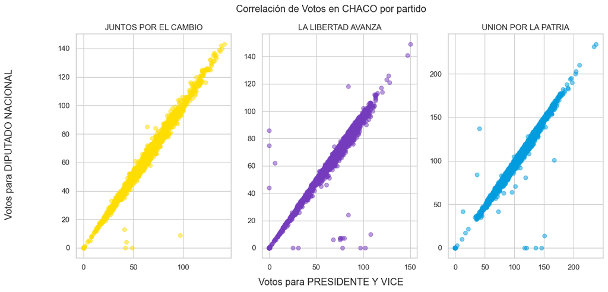

```python
chaco_df = datos_generales_g10[datos_generales_g10['distrito_nombre'] == 'Chaco']
presidenciales_chaco_df = chaco_df[chaco_df['cargo_nombre'] == 'PRESIDENTE Y VICE']
diputados_chaco_df = chaco_df[chaco_df['cargo_nombre'] == 'DIPUTADO NACIONAL']

presidenciales_pivot_chaco = presidenciales_chaco_df.pivot_table(values='votos_cantidad',
                                                                     index=['mesa_id', 'circuito_id'],
                                                                     columns='agrupacion_nombre',
                                                                     aggfunc='sum',
                                                                     fill_value=0).reset_index()

diputados_pivot_chaco = diputados_chaco_df.pivot_table(values='votos_cantidad',
                                                           index=['mesa_id', 'circuito_id'],
                                                           columns='agrupacion_nombre',
                                                           aggfunc='sum',
                                                           fill_value=0).reset_index()

merged_chaco_df = pd.merge(presidenciales_pivot_chaco, diputados_pivot_chaco, on=['mesa_id', 'circuito_id'])

partidos = ['JUNTOS POR EL CAMBIO', 'LA LIBERTAD AVANZA', 'UNION POR LA PATRIA']
fig, axs = plt.subplots(1, 3, figsize = (14, 6))
for i, partido in enumerate(partidos):
    axs[i].scatter(merged_chaco_df[partido + '_x'], merged_chaco_df[partido + '_y'],
                   alpha = 0.5, c = colores_3_partidos[partido])
    axs[i].set_title(f'{partido}')
fig.supxlabel('Votos para PRESIDENTE Y VICE')
fig.supylabel('Votos para DIPUTADO NACIONAL')
fig.suptitle(f'Correlación de Votos en CHACO por partido')
plt.grid(True)
plt.show()
```

Al igual que en el caso de Formosa, en Chaco se observa una fuerte correlación entre ambos cargos por partido.

Aparecen nuevamente mesas donde se votó a Presidente-Vice pero ninguna a Diputados.

En el caso de La Libertad Avanza también ocurre lo contrario en tres mesas: hay votos a Diputados pero ninguno a Presidente-Vice.

#### Santiago del Estero

En Santiago del Estero, solo Juntos por el Cambio presentó, con dicho nombre, candidatos a Presidente-Vice y Diputados.

Además, tanto Unión por la Patria como La Libertad Avanza no presentaron cadidatos del mismo partido.

Es por esto que decidimos saltear este análisis comparativo.

### Detección de mesas anómalas.

Nos interesa poder automatizar la detección de mesas anómalas. Es decir, seleccionar aquellas mesas cuyos resultados difieren, en alguna medida, con lo esperado para realizar una auditoría personalizada.

Algunas definiciones de una mesa anómala podrían ser:

- Mesa que tenga algún partido con un porcentaje de votos superior al percentil 95, o inferior al percentil 5, de los votos de toda la provincia. Se tiene que considerar solo los partidos políticos con un porcentaje lo suficientemente alto (en promedio o mediana) como para no dar falsos positivos. Una cota del 10% de los votos en adelante podría funcionar.
- Mesa que presente un porcentaje alto de votos no positivos (en blanco, nulo, impugnado, etc.). En este caso se podría consultar los resultados de elecciones pasadas (https://www.argentina.gob.ar/dine/resultados-electorales) para detectar si en dicha provincia o sección es común este tipo de voto.
- Mesa cuyos resultados reportados en la base de datos sean distintos al telegrama de la misma. Los telegramas se pueden consultar en la página web de los resultados electorales (https://resultados.gob.ar/).
- Mesa donde el número de votos para un cargo (ej.: Presidente-Vice) sea mucho menor que el de los otros cargos.

Elegimos este último caso y seleccionamos las mesas anómalas.

Tomamos como punto de corte aquellas mesas que tengan una diferencia de más de 30 votos entre Presidente-Vice y el resto de los cargos.

Para identificar a una mesa, no basta solo con **mesa_id**, sino que también necesitamos de **distrito_id**, **seccion_id** y **circuito_id**.

```python
datos_generales_g10[["distrito_id", "seccion_id", "circuito_id", "mesa_id"]].drop_duplicates().shape[0]
```

```
6895
```

Tenemos 6895 mesas únicas. Vemos cuáles son, ordenadas de mayor a menor por diferencia de votos:

```python
df_pivot = datos_generales_g10.pivot_table(values='votos_cantidad',
                                          index=["distrito_id", "seccion_id", "circuito_id", "mesa_id"],
                                          columns='cargo_nombre',
                                          aggfunc='sum',
                                          fill_value=0).reset_index()


df_pivot['diferencia_presidente'] = df_pivot.drop(["distrito_id", "seccion_id", "circuito_id", "mesa_id", 'PRESIDENTE Y VICE'], axis=1).max(axis=1) - df_pivot['PRESIDENTE Y VICE']

umbral = 30
mesas_anomalas = df_pivot[df_pivot['diferencia_presidente'] > umbral].sort_values(by="diferencia_presidente", ascending=False)

print("Nro. de mesas anómalas: ", len(mesas_anomalas))

mesas_anomalas
```

```
Nro. de mesas anómalas:  53
```

| cargo_nombre | distrito_id | seccion_id | circuito_id | mesa_id | DIPUTADO NACIONAL | PARLAMENTO MERCOSUR NACIONAL | PARLAMENTO MERCOSUR REGIONAL | PRESIDENTE Y VICE | SENADOR NACIONAL | diferencia_presidente |
| --- | --- | --- | --- | --- | --- | --- | --- | --- | --- | --- |
| 5958 | 22 | 10 | 00092 | 1532 | 297 | 37 | 297 | 35 | 0 | 262 |
| 6359 | 22 | 18 | 00159 | 1932 | 254 | 15 | 254 | 15 | 0 | 239 |
| 6571 | 22 | 22 | 00192 | 2146 | 247 | 9 | 247 | 11 | 0 | 236 |
| 6541 | 22 | 22 | 00184 | 2113 | 238 | 8 | 233 | 8 | 0 | 230 |
| 5688 | 22 | 6 | 00055 | 1260 | 207 | 3 | 207 | 3 | 0 | 204 |
| 4511 | 22 | 1 | 00004 | 138 | 291 | 98 | 291 | 94 | 0 | 197 |
| 4531 | 22 | 1 | 00004 | 158 | 245 | 54 | 245 | 54 | 0 | 191 |
| 6849 | 22 | 27 | 00224 | 2419 | 277 | 257 | 277 | 98 | 0 | 179 |
| 5265 | 22 | 4 | 00032 | 835 | 186 | 11 | 186 | 11 | 0 | 175 |
| 6248 | 22 | 16 | 00142 | 1823 | 219 | 50 | 219 | 50 | 0 | 169 |
| 5278 | 22 | 4 | 00034 | 849 | 212 | 53 | 215 | 54 | 0 | 161 |
| 6018 | 22 | 12 | 00103 | 1588 | 199 | 40 | 199 | 40 | 0 | 159 |
| 5159 | 22 | 1 | 0008B | 663 | 284 | 128 | 284 | 127 | 0 | 157 |
| 5063 | 22 | 1 | 0007C | 544 | 287 | 138 | 287 | 136 | 0 | 151 |
| 6473 | 22 | 21 | 00180 | 2043 | 289 | 146 | 289 | 145 | 0 | 144 |
| 5437 | 22 | 6 | 00044 | 1007 | 269 | 269 | 269 | 125 | 0 | 144 |
| 4533 | 22 | 1 | 00004 | 160 | 233 | 96 | 226 | 98 | 0 | 135 |
| 6484 | 22 | 21 | 00180 | 2054 | 275 | 146 | 275 | 143 | 0 | 132 |
| 6013 | 22 | 11 | 00102 | 1583 | 176 | 46 | 179 | 48 | 0 | 131 |
| 5167 | 22 | 1 | 0008B | 671 | 199 | 262 | 197 | 135 | 0 | 127 |
| 6024 | 22 | 12 | 00104 | 1594 | 220 | 93 | 220 | 96 | 0 | 124 |
| 6814 | 22 | 27 | 00223 | 2384 | 174 | 48 | 174 | 57 | 0 | 117 |
| 6737 | 22 | 24 | 00204 | 2307 | 155 | 49 | 155 | 49 | 0 | 106 |
| 3567 | 9 | 2 | 00022 | 621 | 269 | 268 | 269 | 168 | 269 | 101 |
| 78 | 6 | 1 | 00009 | 318 | 276 | 276 | 276 | 176 | 0 | 100 |
| 1535 | 6 | 10 | 00074 | 1536 | 233 | 233 | 333 | 233 | 0 | 100 |
| 4644 | 22 | 1 | 00009 | 694 | 290 | 205 | 290 | 197 | 0 | 93 |
| 6202 | 22 | 16 | 00140 | 1777 | 260 | 171 | 260 | 168 | 0 | 92 |
| 5900 | 22 | 9 | 00077 | 1470 | 200 | 115 | 200 | 118 | 0 | 82 |
| 1603 | 6 | 11 | 00078 | 1604 | 261 | 261 | 333 | 261 | 0 | 72 |
| 5579 | 22 | 6 | 00048 | 1149 | 278 | 210 | 278 | 206 | 0 | 72 |
| 309 | 6 | 1 | 00023 | 1011 | 345 | 275 | 275 | 275 | 0 | 70 |
| 5045 | 22 | 1 | 0007C | 526 | 294 | 294 | 294 | 234 | 0 | 60 |
| 5477 | 22 | 6 | 00044 | 1047 | 280 | 280 | 280 | 220 | 0 | 60 |
| 1824 | 6 | 13 | 00088 | 1825 | 248 | 248 | 248 | 192 | 0 | 56 |
| 4521 | 22 | 1 | 00004 | 148 | 282 | 338 | 282 | 282 | 0 | 56 |
| 506 | 6 | 1 | 0008A | 212 | 281 | 281 | 335 | 281 | 0 | 54 |
| 2012 | 6 | 13 | 00094 | 2013 | 261 | 206 | 261 | 211 | 0 | 50 |
| 4088 | 9 | 6 | 00050 | 1143 | 234 | 234 | 284 | 234 | 234 | 50 |
| 5383 | 22 | 6 | 00043 | 953 | 262 | 262 | 312 | 262 | 0 | 50 |
| 4659 | 22 | 1 | 00010 | 709 | 126 | 76 | 126 | 76 | 0 | 50 |
| 5138 | 22 | 1 | 0008B | 642 | 290 | 290 | 290 | 240 | 0 | 50 |
| 4793 | 22 | 1 | 0004A | 196 | 269 | 219 | 270 | 224 | 0 | 46 |
| 2683 | 6 | 24 | 00132 | 2684 | 188 | 144 | 188 | 144 | 0 | 44 |
| 3347 | 9 | 1 | 00005 | 401 | 272 | 272 | 272 | 230 | 272 | 42 |
| 5790 | 22 | 8 | 00071 | 1362 | 267 | 234 | 267 | 230 | 0 | 37 |
| 4762 | 22 | 1 | 0004A | 165 | 323 | 287 | 287 | 286 | 0 | 37 |
| 987 | 6 | 1 | 0019B | 896 | 261 | 298 | 261 | 261 | 0 | 37 |
| 5819 | 22 | 8 | 00072 | 1391 | 156 | 121 | 156 | 123 | 0 | 33 |
| 3480 | 9 | 1 | 00007 | 543 | 280 | 310 | 280 | 277 | 280 | 33 |
| 584 | 6 | 1 | 0008B | 290 | 264 | 297 | 264 | 264 | 0 | 33 |
| 4998 | 22 | 1 | 0007C | 479 | 311 | 279 | 311 | 279 | 0 | 32 |
| 3164 | 9 | 1 | 00003 | 218 | 260 | 257 | 290 | 259 | 260 | 31 |

Bajo el criterio mencionado, existen 53 mesas anómalas. Analizamos cómo se distribuye la diferencia de votos entre Presidente y el resto de los cargos:

```python
mesas_anomalas['diferencia_presidente'].describe()
```

```
count     53.000000
mean     105.528302
std       64.302053
min       31.000000
25%       50.000000
50%       93.000000
75%      151.000000
max      262.000000
Name: diferencia_presidente, dtype: float64
```

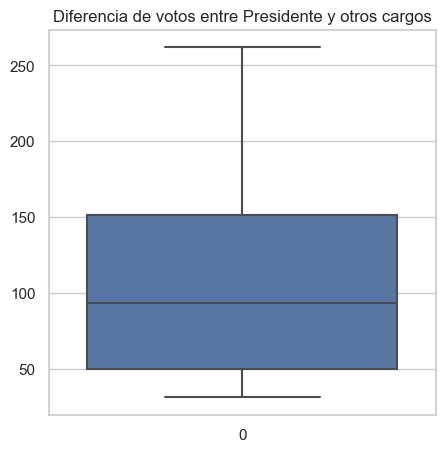

```python
sns.set(style="whitegrid")
plt.figure(figsize=(5, 5))
sns.boxplot(data=mesas_anomalas['diferencia_presidente'].values)
plt.title("Diferencia de votos entre Presidente y otros cargos")
plt.show()
```

Como puede verse en los percentiles y en el boxplot, las diferencias de votos están bastante por encima de los 30 puestos de umbral.

La mediana de votos es 93 y el máximo 262. A modo de optimizar la auditoría, se podría investigar primero las mesas con mayores discrepancias.